# API - Case_Complete

This was a workshop that was done in LionBase's first year. As APIs are pretty general method, I felt this still illustrated the concepts well.

The tone of this case is definitely different from the other cases. Feel free to provide feedback.

## Overview

Problem: Valentine's Day is tomorrow and you need to find a restaurant for your date (or for yourself)!! There are so many options though... how can we pick a satisfactory restaurant?

Solution: We will be using the Yelp API to programmatically select the perfect restaurant for Valentine's. After all, nothing says "I care" like building out a data science algorithm for your date!

Beyond just querying, we will also be doing some basic data visualizations.

## Step 0: Import Modules

```python
import numpy as np # data processing libraries
import pandas as pd

import matplotlib.pyplot as plt # data visualization librarY

import requests # for grabbing web requests
import json # common data type
```

## Step 1: Get API Credentials

https://www.yelp.com/developers/documentation/v3

log into yelp (top right hand corner of the page)

Click Create App on the left hand menu bar

Enter app info (leave optional stuff blank)

Copy the client id and client secret to a secure place (this notebook should do the trick or use a text file!)

```python
CLIENT_ID = "" # paste client id here
API_KEY = "" # paste api key (the client secret) here
```

```python
# API constants, you shouldn't have to change these.
API_HOST = 'https://api.yelp.com' #The API url header
SEARCH_PATH = '/v3/businesses/search' #The path for an API request to find businesses
BUSINESS_PATH = '/v3/businesses/'  # The path to get data for a single business
```

## Step 2: Get Restaurants

```python
def get_restaurants(api_key,location,number=15):
    import requests

    #First we get the access token
    #Set up the search data dictionary
    search_data = {
    'term': "restaurant",
    'location': location.replace(' ', '+'),
    'limit': number
    }
    url = API_HOST + SEARCH_PATH # this is equivalent to https://api.yelp.com/v3/businesses/search
    headers = {
        'Authorization': 'Bearer %s' % api_key,
    }
    response = requests.request('GET', url, headers=headers, params=search_data).json() # send request using authorization credentials
    businesses = response.get('businesses')
    return businesses
```

```python
get_restaurants(API_KEY,"Columbia University, New York, NY")
```

```
[{'alias': 'ortomare-ristorante-pizzeria-new-york-2',
  'categories': [{'alias': 'wine_bars', 'title': 'Wine Bars'},
   {'alias': 'italian', 'title': 'Italian'},
   {'alias': 'pizza', 'title': 'Pizza'}],
  'coordinates': {'latitude': 40.80124, 'longitude': -73.96161},
  'display_phone': '(212) 665-2970',
  'distance': 713.7431557007849,
  'id': 'WYdrEMBXzOcxffpQczHKww',
  'image_url': 'https://s3-media2.fl.yelpcdn.com/bphoto/q1qKvlHHehEx6RwZBWrHmg/o.jpg',
  'is_closed': False,
  'location': {'address1': '994 Columbus Ave',
   'address2': '',
   'address3': None,
   'city': 'New York',
   'country': 'US',
   'display_address': ['994 Columbus Ave', 'New York, NY 10025'],
   'state': 'NY',
   'zip_code': '10025'},
  'name': 'Ortomare Ristorante Pizzeria',
  'phone': '+12126652970',
  'rating': 5.0,
  'review_count': 1,
  'transactions': ['pickup', 'delivery'],
  'url': 'https://www.yelp.com/biz/ortomare-ristorante-pizzeria-new-york-2?adjust_creative=_QAphCvzqLQ1DVhvkuMrrA&utm_campaign=yelp_api_v3&utm_medium=api_v3_business_search&utm_source=_QAphCvzqLQ1DVhvkuMrrA'},
 {'alias': 'flat-top-new-york',
  'categories': [{'alias': 'newamerican', 'title': 'American (New)'},
   {'alias': 'cafes', 'title': 'Cafes'},
   {'alias': 'breakfast_brunch', 'title': 'Breakfast & Brunch'}],
  'coordinates': {'latitude': 40.810041, 'longitude': -73.958693},
  'display_phone': '(646) 820-7735',
  'distance': 424.3853457755761,
  'id': 'E2mNgb479B3BCfwi2G_KdQ',
  'image_url': 'https://s3-media1.fl.yelpcdn.com/bphoto/y2YlqtpKU2tciozvngNbsg/o.jpg',
  'is_closed': False,
  'location': {'address1': '1241 Amsterdam Ave',
   'address2': '',
   'address3': '',
   'city': 'New York',
   'country': 'US',
   'display_address': ['1241 Amsterdam Ave', 'New York, NY 10027'],
```

[output cut: 302 more lines]

```
  'location': {'address1': '2895 Broadway',
   'address2': '',
   'address3': '',
   'city': 'New York',
   'country': 'US',
   'display_address': ['2895 Broadway', 'New York, NY 10025'],
   'state': 'NY',
   'zip_code': '10025'},
  'name': 'Mill Korean',
  'phone': '+12126667653',
  'price': '$$',
  'rating': 3.0,
  'review_count': 307,
  'transactions': ['pickup', 'delivery'],
  'url': 'https://www.yelp.com/biz/mill-korean-new-york?adjust_creative=_QAphCvzqLQ1DVhvkuMrrA&utm_campaign=yelp_api_v3&utm_medium=api_v3_business_search&utm_source=_QAphCvzqLQ1DVhvkuMrrA'}]
```

### Side Note: JSON

The data is returned above is being formatted in JSON (Javascript Object Notation), which is one of the most popular and important forms of standardized data formatting. It gives us a human-readable collection of data that we can logically process.

**It is standard for APIs to format data using JSON, so it is important to be familiar with this**

```python
json_dict= {} # JSON object can be a dictionary
json_dict['a'] = 1
json_dict['b'] = 2
json_dict['c'] = 3

json_array = [1,2,3] # JSON object can be an array

print('The following are JSON objects in their simplest form.')
print(json_dict)
print(json_array)
```

```
The following are JSON objects in their simplest form.
{'a': 1, 'b': 2, 'c': 3}
[1, 2, 3]
```

```python
x = '{"A":[1,2,3,{"B":24}]}' # Example of JSON object that is nested
print(x)
```

```
{"A":[1,2,3,{"B":24}]}
```

```python
data_string = '[{"b": [2, 4], "c": 3.0, "a": "A"},34]'
python_data = json.loads(data_string) # converts json object to python data object
print(type(data_string))
print(python_data)
data_string
print(type(python_data))
```

```
<class 'str'>
[{'b': [2, 4], 'c': 3.0, 'a': 'A'}, 34]
<class 'list'>
```

```python
import json
data_string = json.dumps(python_data, indent = 2) # converts python data object to json object, indent allows for nicer formatting when printed
print(type(data_string))
print(data_string)
```

```
<class 'str'>
[
  {
    "b": [
      2,
      4
    ],
    "c": 3.0,
    "a": "A"
  },
  34
]
```

JSON can effectively be seen as a more programmatic set up of nested dictionaries and lists (though in its simplest form, it can just be a single-layer dictionary or list). More info on JSON can be found here: https://www.w3resource.com/JSON/structures.php

### Practice JSON!

Come up with a JSON object that represents students, and includes information on name and favorite flower (in the spirit of Valentine's ofc).

```python
# insert code here

student_json = [
    {'Students':[
     {'name': 'Ibrahim',
     'flower': 'rose'},
     {'name': 'Kev',
     'flower': 'baby-breath'}
    ]
    }

]
```

## Step 2: Filter

What are some easy filters we want to apply?

- Price
- Rating
- Takes Reservation
- Location

```python
def filter_restaurants(price, min_rating, reservation, location):
    restaurants = get_restaurants(API_KEY, location)

    acceptable_restaurants = {}

    for r in restaurants:

        if 'rating' in r.keys():
            rating = r['rating']
        else:
            rating = 0
        if 'price' in r.keys():
            cost = r['price']
        else:
            cost = 0
        if 'restaurant_reservation' in r['transactions']:
            can_reserve = True
        else:
            can_reserve = False

        if float(rating) >= min_rating and can_reserve == reservation and (len(cost) <= len(price)):
            acceptable_restaurants[r['alias']] = r['name']

    return(acceptable_restaurants)
```

```python
filtered = filter_restaurants('$$', 4, True, "Columbia University, New York, NY")
filtered
```

```
{'flat-top-new-york': 'Flat Top',
 'lolos-seafood-shack-new-york': "Lolo's Seafood Shack",
 'pisticci-new-york': 'Pisticci'}
```

## Practice Step!

Write code that returns the phone number of Flat Top.

```python
# insert code here
get_restaurants(API_KEY,"Columbia University, New York, NY")

for r in restaurant:
  if r['name'] == 'Flat Top':
     print(r['phone'])
```

## Step 3: Get Reviews

OK! We've filtered out a bunch of restaurants, but what are people actually saying?

```python
def get_business_review(api_key,business_id):
    import json
    import requests
    business_path = BUSINESS_PATH + business_id+"/reviews" # for flat top, this is equivalent to /v3/businesses/flat-top-new-york/reviews
    url = API_HOST + business_path # for flat top, this is equivalent to https://api.yelp.com/v3/businesses/flat-top-new-york/reviews

    headers = {
        'Authorization': 'Bearer %s' % api_key,
    }


    response = requests.request('GET', url, headers=headers).json()

    review_text = ''
    for review in response['reviews']:
        review_text += review['text']
    return review_text
```

```python
for restaurant in filtered.keys():
    print('\n*****{} REVIEWS'.format(filtered[restaurant]))
    print(get_business_review(API_KEY,restaurant))
```

```
*****Flat Top REVIEWS
Was in a hurry for brunch this morning and found this place on Yelp. We were able to make a reservation on the app and were outta bed, dressed, and seated...I've only eaten in the restaurant a couple times, but their delivery is great. Shrimp and grits were tasty, if a bit sweet; brunch cobb salad w…

*****Lolo's Seafood Shack REVIEWS
Great food! That's why you come here!

Love the small shack feel to the place. I got the shrimp boil which was excellent. Their signature sauce is great...I  have ranked here my  Harlem must go list since I started exploring Harlem. And finally could come here for Saturday brunch
Lots  of my friends Harlem...Very rustic place that's not big on looks but great on flavor. I had the coconut shrimp basket that came with garlic fries. I added an order of sweet potato...

*****Pisticci REVIEWS
And Francis!
And Quentin!
Every experience here gets better and better.

Just wanna eat here everyday, it's the perfect restaurant. Nailed it guys.I spent $30 on an Uber to come to Pisticci and absolutely do not regret it! The atmosphere is busy but still quite cozy at the same time. Here is a mix...Brunch food is better than dinner, but the atmosphere is great at night.…
```

## Step 4: Let's Compare Some Metrics!

However, maybe we want a view that's more contextual! Let's compare all the restaurants in the Columbia area based on number of reviews.

Question -- why would comparing the number of reviews be helpful?

```python
def get_number_of_reviews(location):
    restaurants = get_restaurants(API_KEY,location)

    num_reviews = {}
    for r in restaurants:
        num_reviews[r['name']] = r['review_count']

    return(num_reviews)
```

```python
num_reviews = get_number_of_reviews("Columbia University, New York, NY")
num_reviews
```

```
{'Atlas Kitchen': 50,
 'Dig Inn': 289,
 'Elysian Fields Cafe': 6,
 'Flat Top': 407,
 'Jin Ramen - West Harlem': 988,
 "Lolo's Seafood Shack": 588,
 'Marlow Bistro': 233,
 'Mill Korean': 307,
 'Ortomare Ristorante Pizzeria': 1,
 'Osteria 106': 68,
 'Pisticci': 777,
 'Red Hot Hot Pot': 57,
 'Saiguette': 529,
 'Szechuan Garden': 230,
 'Thai Market': 916}
```

```python
%matplotlib inline
def plot_review_count(names, review_count):
    plt.figure(figsize=(20,8))
    plt.bar(names, review_count)

    plt.xlabel('Restaurant Name', fontsize=14)
    plt.ylabel('Review Count', fontsize=14)
    plt.xticks(names, fontsize=10, rotation=30)
    plt.title('Review Count for Each Restaurant')

    plt.show()
```

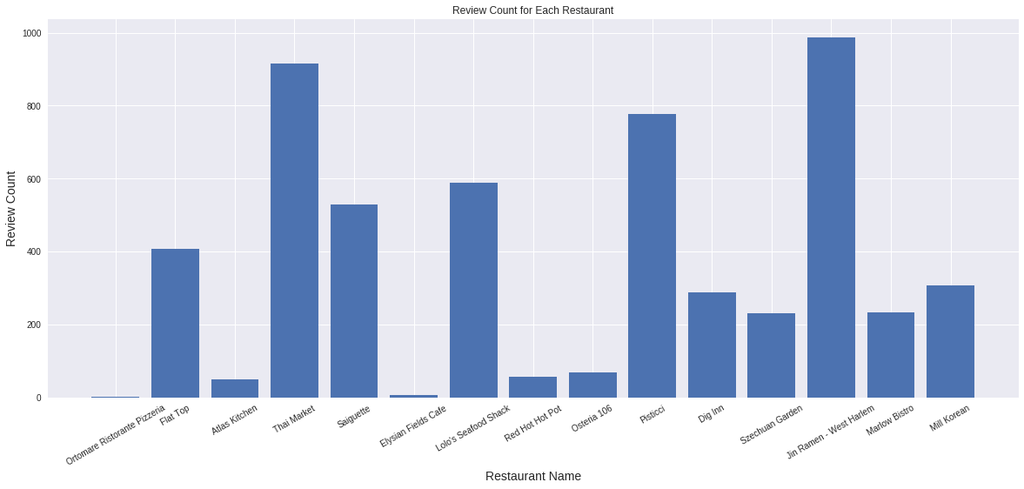

```python
names = list(num_reviews.keys())
review_count = list(num_reviews.values())
plot_review_count(names, review_count)
```

### ADVANCED: Let's put this in descending order

Question -- why would we want to do descending order instead of ascending order?

```python
num_reviews_sorted = sorted(num_reviews.items(), reverse = True, key=lambda x: x[1])
num_reviews_sorted
```

```
[('Jin Ramen - West Harlem', 988),
 ('Thai Market', 916),
 ('Pisticci', 777),
 ("Lolo's Seafood Shack", 588),
 ('Saiguette', 529),
 ('Flat Top', 407),
 ('Mill Korean', 307),
 ('Dig Inn', 289),
 ('Marlow Bistro', 233),
 ('Szechuan Garden', 230),
 ('Osteria 106', 68),
 ('Red Hot Hot Pot', 57),
 ('Atlas Kitchen', 50),
 ('Elysian Fields Cafe', 6),
 ('Ortomare Ristorante Pizzeria', 1)]
```

```
['Jin Ramen - West Harlem', 'Thai Market', 'Pisticci', "Lolo's Seafood Shack", 'Saiguette', 'Flat Top', 'Mill Korean', 'Dig Inn', 'Marlow Bistro', 'Szechuan Garden', 'Osteria 106', 'Red Hot Hot Pot', 'Atlas Kitchen', 'Elysian Fields Cafe', 'Ortomare Ristorante Pizzeria']
[988, 916, 777, 588, 529, 407, 307, 289, 233, 230, 68, 57, 50, 6, 1]
```

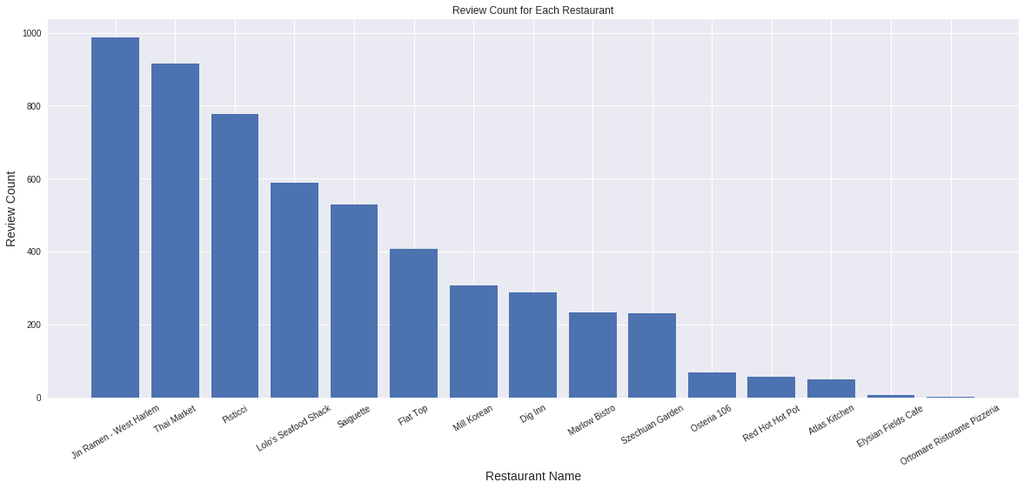

```python
names_sorted = []
review_count_sorted = []

for item in num_reviews_sorted:
    # item - '(Jin Ramen - West Harlem, 988)'
    names_sorted.append(item[0])
    review_count_sorted.append(item[1])

print(names_sorted)
print(review_count_sorted)

plot_review_count(names_sorted, review_count_sorted)
```

## Let's Compare with the Original Filtered Set

```python
filtered
```

```
{'flat-top-new-york': 'Flat Top',
 'lolos-seafood-shack-new-york': "Lolo's Seafood Shack",
 'pisticci-new-york': 'Pisticci'}
```

Flat Top, Lolo's Seafood Shack, and Pisticci all are in the upper half of review counts! These are good votes of confidence for them. Out of the three, Pisticci has the most reviews.

```python
for restaurant in filtered.keys():
    print('\n*****{} REVIEWS'.format(filtered[restaurant]))
    print(get_business_review(API_KEY,restaurant))
```

```
*****Flat Top REVIEWS
Was in a hurry for brunch this morning and found this place on Yelp. We were able to make a reservation on the app and were outta bed, dressed, and seated...I've only eaten in the restaurant a couple times, but their delivery is great. Shrimp and grits were tasty, if a bit sweet; brunch cobb salad w…

*****Lolo's Seafood Shack REVIEWS
Great food! That's why you come here!

Love the small shack feel to the place. I got the shrimp boil which was excellent. Their signature sauce is great...I  have ranked here my  Harlem must go list since I started exploring Harlem. And finally could come here for Saturday brunch
Lots  of my friends Harlem...Very rustic place that's not big on looks but great on flavor. I had the coconut shrimp basket that came with garlic fries. I added an order of sweet potato...

*****Pisticci REVIEWS
And Francis!
And Quentin!
Every experience here gets better and better.

Just wanna eat here everyday, it's the perfect restaurant. Nailed it guys.I spent $30 on an Uber to come to Pisticci and absolutely do not regret it! The atmosphere is busy but still quite cozy at the same time. Here is a mix...Brunch food is better than dinner, but the atmosphere is great at night.…
```

Reading the reviews, only Pisticci has notes about having a great atmosphere at night, although all three are strong for brunch.

## FINAL RESTAURANT CHOICE: PISTICCI

*Tangent from Kev:* The one time I went to Pisticci my table had a small fire... so... yeet.